# Stout_casestudy_2

```python
import pandas as pd
import numpy as np
import matplotlib.pyplot as plt
import seaborn as sns
from sklearn.model_selection import train_test_split
from sklearn.impute import SimpleImputer
import chart_studio.plotly as py
import plotly.offline as po
import plotly.graph_objs as pg
%matplotlib inline
from IPython.core.interactiveshell import InteractiveShell
InteractiveShell.ast_node_interactivity = "all"
import warnings
warnings.filterwarnings("ignore")
import squarify
```

```python
data=pd.read_csv("C:/Users/deeps/OneDrive/Desktop/Ms/Interview/Case2/casestudy.csv")
data.head(10)
```

|  | Unnamed: 0 | customer_email | net_revenue | year |
| --- | --- | --- | --- | --- |
| 0 | 0 | nhknapwsbx@gmail.com | 249.92 | 2015 |
| 1 | 1 | joiuzbvcpn@gmail.com | 87.61 | 2015 |
| 2 | 2 | ukkjctepxt@gmail.com | 168.38 | 2015 |
| 3 | 3 | gykatilzrt@gmail.com | 62.40 | 2015 |
| 4 | 4 | mmsgsrtxah@gmail.com | 43.08 | 2015 |
| 5 | 5 | mobvusnzfr@gmail.com | 39.44 | 2015 |
| 6 | 6 | kxwkqvacsv@gmail.com | 171.46 | 2015 |
| 7 | 7 | iqmnugdcjs@gmail.com | 111.99 | 2015 |
| 8 | 8 | baiikostmd@gmail.com | 170.70 | 2015 |
| 9 | 9 | lfeafnigbu@gmail.com | 54.99 | 2015 |

```python
data.info()
```

```
<class 'pandas.core.frame.DataFrame'>
RangeIndex: 685927 entries, 0 to 685926
Data columns (total 4 columns):
 #   Column          Non-Null Count   Dtype
---  ------          --------------   -----
 0   Unnamed: 0      685927 non-null  int64
 1   customer_email  685927 non-null  object
 2   net_revenue     685927 non-null  float64
 3   year            685927 non-null  int64
dtypes: float64(1), int64(2), object(1)
memory usage: 20.9+ MB
```

### Observation:

1.The given dataset contains 685927 data points .

2.The dataset columns have no null values, so missing values handling is not required.

3.There is 1 Categorical feature and rest are numerical features.

4.The dataframe consumed 20.9 MB of memory.

```python
#Analyse duplicates in the dataset.
duplicatedRows=data[data.duplicated()]
print("Number of duplicate datapoints are:",len(duplicatedRows))
```

```
Number of duplicate datapoints are: 0
```

### Observation:

The given dataset has no duplicate data points , so handling is not required.

## Data Analysis

### For each year we need the following information:

1.Total revenue for the current year

2.New Customer Revenue e.g., new customers not present in previous year only

3.Existing Customer Growth. To calculate this, use the Revenue of existing customers for current year  
 –(minus) Revenue of existing customers from the previous year

4.Revenue lost from attrition

5.Existing Customer Revenue Current Year

6.Existing Customer Revenue Prior Year

7.Total Customers Current Year

8.Total Customers Previous Year

9.New Customers

10.Lost Customers

```python
print(f"There are {data.shape[0]} rows and {data.shape[1]} columns in the dataframe")
print()
print()
print("Column names:",list(data.columns))
```

```
There are 685927 rows and 4 columns in the dataframe


Column names: ['Unnamed: 0', 'customer_email', 'net_revenue', 'year']
```

```python
current_years=data["year"].unique()[::-1]
print("Years for analysis are :",current_year)
```

[output not shown]

```python
for current_year in current_years:
    #Print the current year.
    print("Currrent Year: ",current_year,"\n")

    #Fetch the total sum of revenue for the current year.
    revenue = data[data["year"]==current_year]["net_revenue"].values.sum()
    print("1) Total revenue for the current year",revenue)
    print("-"*100)
    print()
    print("2) New Customer Revenue e.g., new customers not present in previous year only")

    #get the previous years customer values.
    A  = set(data[data["year"] < current_year]["customer_email"].values)

    #Get the customers of current year.
    B  = set(data[data["year"] == current_year]["customer_email"].values)

    #Fetch the customers not present in previous years but present in current year.
    new_customer_list=list(B.difference(A))


    curr_year = data[data["year"]==current_year].set_index("customer_email")

    curr_year.loc[new_customer_list][["net_revenue"]]

    print("-"*100)
    print()
    print("3) Existing Customer Growth.")


    # Set the previous year .
    previous_year = current_year - 1

    #Fetch the customers in previous of current year.
    C = set(data[data["year"] == previous_year]["customer_email"].values)


    prev_year = data[data["year"]==previous_year].set_index("customer_email")

    #Fetch the customers that are common in current year and previous year.
    existing_users = C.intersection(B)


    #fetch the revenue of current year and prvious year.
    merged_data = pd.concat([curr_year.loc[existing_users][["net_revenue"]],prev_year.loc[existing_users][["net_revenue"]]],axis=1)

    merged_data.columns = ("current_year_revenue","previous_year_revenue")

    #Find the increase in revenue between current year and previous year.
    merged_data["Increase_in_revenue"] = merged_data["current_year_revenue"].values - merged_data["previous_year_revenue"].values

    inc_rev = merged_data[merged_data["Increase_in_revenue"]>0]

    inc_rev_neg = merged_data[merged_data["Increase_in_revenue"]<0]

    #Negate the negetive values.
    inc_rev_neg["Increase_in_revenue"] = inc_rev_neg["Increase_in_revenue"].values*-1


    inc_rev_neg.columns = (inc_rev_neg.columns[0],inc_rev_neg.columns[1],"Decrease_In_Revenue")

    inc_rev[["Increase_in_revenue"]]
    print("-"*100)
    print()
    print("4) Revenue lost from attrition")
    inc_rev_neg[["Decrease_In_Revenue"]]

    print("-"*100)
    print()
    print("5) Existing Customer Revenue Current Year")

    merged_data[["current_year_revenue"]]

    print("-"*100)
    print()
    print("6) Existing Customer Revenue Prior Year")
    merged_data[["previous_year_revenue"]]

    print("-"*100)
    print()
    print("7) Total Customers Current Year :", len(B) )
    print("-"*100)
    print()
    print("8) Total Customers Previous Year :", len(C))
    print("-"*100)
    print()



    print("9) Total New Customers:", len(B.difference(C)))
    print("-"*100)
    print()
    print("10) Total Lost Customers:",len(C.difference(B)))
    print()
    print("-"*100)
    print()

    print("="*100)
    print()
    print()
```

```
Currrent Year:  2017

1) Total revenue for the current year 31417495.030000016
----------------------------------------------------------------------------------------------------

2) New Customer Revenue e.g., new customers not present in previous year only
```

| customer_email | net_revenue |
| --- | --- |
| hejxkpwwcv@gmail.com | 242.53 |
| pcatmbrwmm@gmail.com | 35.03 |
| hwghtgtcen@gmail.com | 244.63 |
| qzrasskrxi@gmail.com | 214.91 |
| taoqhaeame@gmail.com | 87.57 |
| ... | ... |
| bxrlmlekjz@gmail.com | 37.66 |
| mthuhxeeua@gmail.com | 174.44 |
| tohgrqfnlf@gmail.com | 188.50 |
| tfwsktccti@gmail.com | 184.93 |
| kmfmmmikjr@gmail.com | 87.74 |

228262 rows × 1 columns

```
----------------------------------------------------------------------------------------------------

3) Existing Customer Growth.
```

| customer_email | Increase_in_revenue |
| --- | --- |
| gaoeymvtfl@gmail.com | 15.24 |
| rpnhjqxucq@gmail.com | 119.33 |
| oshquvglcg@gmail.com | 95.99 |
| lbeipdjvpu@gmail.com | 51.45 |
| teesiohlrh@gmail.com | 3.73 |
| ... | ... |
| jpchkiudmf@gmail.com | 145.35 |
| snojdubngm@gmail.com | 132.64 |
| kpubgykkxi@gmail.com | 66.21 |
| ifrbfxefhj@gmail.com | 170.06 |
| bicqmfznuv@gmail.com | 67.32 |

10595 rows × 1 columns

```
----------------------------------------------------------------------------------------------------

4) Revenue lost from attrition
```

| customer_email | Decrease_In_Revenue |
| --- | --- |
| jhusqhfsnt@gmail.com | 18.37 |
| wpvoxfeunb@gmail.com | 122.25 |
| wnvpgmlykq@gmail.com | 103.89 |
| qzoogtrmdo@gmail.com | 139.19 |
| gglmvezjwh@gmail.com | 35.63 |
| ... | ... |
| tiosrtwkcw@gmail.com | 46.80 |
| miegpwelcu@gmail.com | 219.35 |
| ouvvhqgdqr@gmail.com | 54.37 |
| pleivcwnxo@gmail.com | 50.59 |
| aimebibhiu@gmail.com | 37.67 |

10362 rows × 1 columns

```
----------------------------------------------------------------------------------------------------

5) Existing Customer Revenue Current Year
```

| customer_email | current_year_revenue |
| --- | --- |
| jhusqhfsnt@gmail.com | 32.40 |
| gaoeymvtfl@gmail.com | 110.46 |
| wpvoxfeunb@gmail.com | 58.98 |
| wnvpgmlykq@gmail.com | 13.83 |
| qzoogtrmdo@gmail.com | 51.54 |
| ... | ... |
| aimebibhiu@gmail.com | 147.76 |
| snojdubngm@gmail.com | 213.30 |
| kpubgykkxi@gmail.com | 94.37 |
| ifrbfxefhj@gmail.com | 240.59 |
| bicqmfznuv@gmail.com | 206.21 |

20959 rows × 1 columns

```
----------------------------------------------------------------------------------------------------

6) Existing Customer Revenue Prior Year
```

| customer_email | previous_year_revenue |
| --- | --- |
| jhusqhfsnt@gmail.com | 50.77 |
| gaoeymvtfl@gmail.com | 95.22 |
| wpvoxfeunb@gmail.com | 181.23 |
| wnvpgmlykq@gmail.com | 117.72 |
| qzoogtrmdo@gmail.com | 190.73 |
| ... | ... |
| aimebibhiu@gmail.com | 185.43 |
| snojdubngm@gmail.com | 80.66 |
| kpubgykkxi@gmail.com | 28.16 |
| ifrbfxefhj@gmail.com | 70.53 |
| bicqmfznuv@gmail.com | 138.89 |

20959 rows × 1 columns

```
----------------------------------------------------------------------------------------------------

7) Total Customers Current Year : 249987
----------------------------------------------------------------------------------------------------

8) Total Customers Previous Year : 204646
----------------------------------------------------------------------------------------------------

9) Total New Customers: 229028
----------------------------------------------------------------------------------------------------

10) Total Lost Customers: 183687

----------------------------------------------------------------------------------------------------

====================================================================================================


Currrent Year:  2016

1) Total revenue for the current year 25730943.59
----------------------------------------------------------------------------------------------------

2) New Customer Revenue e.g., new customers not present in previous year only
```

| customer_email | net_revenue |
| --- | --- |
| veaayoagni@gmail.com | 113.77 |
| jhusqhfsnt@gmail.com | 50.77 |
| qiwupncgnh@gmail.com | 188.61 |
| wpvoxfeunb@gmail.com | 181.23 |
| ydacqbaihm@gmail.com | 86.86 |
| ... | ... |
| ifrbfxefhj@gmail.com | 70.53 |
| qhgyuprvph@gmail.com | 68.50 |
| pxagiqgcum@gmail.com | 11.81 |
| bicqmfznuv@gmail.com | 138.89 |
| ncyptjiyxb@gmail.com | 209.98 |

145062 rows × 1 columns

```
----------------------------------------------------------------------------------------------------

3) Existing Customer Growth.
```

| customer_email | Increase_in_revenue |
| --- | --- |
| dauifbbbxn@gmail.com | 24.53 |
| wnvpgmlykq@gmail.com | 75.54 |
| jmcqotoodh@gmail.com | 8.26 |
| dvnczjdkck@gmail.com | 36.28 |
| zzeiqwssxb@gmail.com | 15.42 |
| ... | ... |
| eungrfqkyc@gmail.com | 25.90 |
| fvtoumpsfh@gmail.com | 128.14 |
| jshajmgfgq@gmail.com | 122.06 |
| sgtdgvxpfl@gmail.com | 117.97 |
| gfuieqenow@gmail.com | 41.81 |

29921 rows × 1 columns

```
----------------------------------------------------------------------------------------------------

4) Revenue lost from attrition
```

| customer_email | Decrease_In_Revenue |
| --- | --- |
| gaoeymvtfl@gmail.com | 106.42 |
| wzcbcvzvns@gmail.com | 92.99 |
| qudtxcsvfk@gmail.com | 97.56 |
| rpnhjqxucq@gmail.com | 42.25 |
| evfxzmprad@gmail.com | 184.80 |
| ... | ... |
| zumackrlcf@gmail.com | 107.51 |
| npqcpcahfg@gmail.com | 128.92 |
| hsxqbextbi@gmail.com | 126.34 |
| zemcpyzdmp@gmail.com | 68.96 |
| lfceyxsjru@gmail.com | 130.60 |

29662 rows × 1 columns

```
----------------------------------------------------------------------------------------------------

5) Existing Customer Revenue Current Year
```

| customer_email | current_year_revenue |
| --- | --- |
| gaoeymvtfl@gmail.com | 95.22 |
| dauifbbbxn@gmail.com | 238.78 |
| wnvpgmlykq@gmail.com | 117.72 |
| wzcbcvzvns@gmail.com | 89.79 |
| qudtxcsvfk@gmail.com | 84.11 |
| ... | ... |
| gfuieqenow@gmail.com | 201.71 |
| npqcpcahfg@gmail.com | 89.19 |
| hsxqbextbi@gmail.com | 34.24 |
| zemcpyzdmp@gmail.com | 32.99 |
| lfceyxsjru@gmail.com | 101.50 |

59584 rows × 1 columns

```
----------------------------------------------------------------------------------------------------

6) Existing Customer Revenue Prior Year
```

| customer_email | previous_year_revenue |
| --- | --- |
| gaoeymvtfl@gmail.com | 201.64 |
| dauifbbbxn@gmail.com | 214.25 |
| wnvpgmlykq@gmail.com | 42.18 |
| wzcbcvzvns@gmail.com | 182.78 |
| qudtxcsvfk@gmail.com | 181.67 |
| ... | ... |
| gfuieqenow@gmail.com | 159.90 |
| npqcpcahfg@gmail.com | 218.11 |
| hsxqbextbi@gmail.com | 160.58 |
| zemcpyzdmp@gmail.com | 101.95 |
| lfceyxsjru@gmail.com | 232.10 |

59584 rows × 1 columns

```
----------------------------------------------------------------------------------------------------

7) Total Customers Current Year : 204646
----------------------------------------------------------------------------------------------------

8) Total Customers Previous Year : 231294
----------------------------------------------------------------------------------------------------

9) Total New Customers: 145062
----------------------------------------------------------------------------------------------------

10) Total Lost Customers: 171710

----------------------------------------------------------------------------------------------------

====================================================================================================


Currrent Year:  2015

1) Total revenue for the current year 29036749.189999994
----------------------------------------------------------------------------------------------------

2) New Customer Revenue e.g., new customers not present in previous year only
```

| customer_email | net_revenue |
| --- | --- |
| zcnkotxvji@gmail.com | 126.84 |
| fpymzrhsad@gmail.com | 90.20 |
| zczckackgx@gmail.com | 205.46 |
| tjjvlcfznk@gmail.com | 13.44 |
| lieluktlmw@gmail.com | 115.15 |
| ... | ... |
| pczvdytfjg@gmail.com | 104.44 |
| npqcpcahfg@gmail.com | 218.11 |
| tcdmuqsben@gmail.com | 71.92 |
| mxtuuauwjv@gmail.com | 94.20 |
| lnoagzxbyz@gmail.com | 170.36 |

231294 rows × 1 columns

```
----------------------------------------------------------------------------------------------------

3) Existing Customer Growth.
```

|  | Increase_in_revenue |
| --- | --- |
| customer_email |  |

```
----------------------------------------------------------------------------------------------------

4) Revenue lost from attrition
```

|  | Decrease_In_Revenue |
| --- | --- |
| customer_email |  |

```
----------------------------------------------------------------------------------------------------

5) Existing Customer Revenue Current Year
```

|  | current_year_revenue |
| --- | --- |
| customer_email |  |

```
----------------------------------------------------------------------------------------------------

6) Existing Customer Revenue Prior Year
```

|  | previous_year_revenue |
| --- | --- |
| customer_email |  |

```
----------------------------------------------------------------------------------------------------

7) Total Customers Current Year : 231294
----------------------------------------------------------------------------------------------------

8) Total Customers Previous Year : 0
----------------------------------------------------------------------------------------------------

9) Total New Customers: 231294
----------------------------------------------------------------------------------------------------

10) Total Lost Customers: 0

----------------------------------------------------------------------------------------------------

====================================================================================================
```

### Observation:

1.Based on the analysis ,it is observed that total revenue for the year '2017' is the highest.

2.For the year , '2017' total current customers are 249987 and when compared to previous year 229028 new customers were added.It is also observed that 183687 of the customers were lost.

3.For the year , '2016' total current customers are 204646 and when compared to previous year 145062 new customers were added.It is also observed that 171710 of the customers were lost.

4.In the given dataset,the 2015 was the least year data provided , so much analysis with respect to previous year could not be done.Therefore total current customers are the total new customers which is 231294 and none are lost customers.

## Plots

```python
#total revenue for every year
X_years=data.year.unique()
Y_sumrev=data.groupby(['year']).sum()["net_revenue"]
```

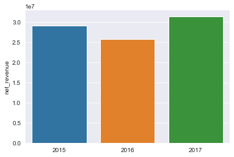

```python
sns.set_style('darkgrid')
barplot=sns.barplot(X_years, Y_sumrev)
plt.show()
```

```python
#total customers for every year
Y_cust=data.groupby(['year']).count()["customer_email"]
```

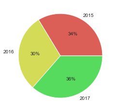

```python
colors = sns.color_palette('hls')
pi_plot=plt.pie(Y_cust, labels=X_years, autopct='%.0f%%',colors=colors )
plt.show()
```

### Observation:

For the number of customers and total net revenue , 2017 year is leading.

----------------------------------------------------- The End ----------------------------------------------------------